# Lab 6: Practice Problems

```r
library(tidyverse)
options(repr.plot.width=8)
```

```r
rand_idx = runif(1000, min=1, max=dim(diamonds)[1])
dm = diamonds[rand_idx, ]
names(dm)
dim(dm)
```

1. 'carat'

2. 'cut'

3. 'color'

4. 'clarity'

5. 'depth'

6. 'table'

7. 'price'

8. 'x'

9. 'y'

10. 'z'

1. 1000

2. 10

# Reproduce the following plots

[figure not shown]

```r
# p1 = ggplot() +
#     geom_point() +
#     facet_wrap()
# print(p1)
```

## Geometric objects

So far we have plotted the points in a fundamental manner. We might be interested in the linear trends of the data that we have.

[figure not shown]

```r
# p2 = ggplot() +
#     geom_point() +
#     geom_smooth()
# print(p2)
```

### 3.6.1 Exercise

1. What geom would you use to draw a line chart? A boxplot? A histogram? An bar chart?
2. Run this code in your head and predict what the output will look like. A reference is here: https://ggplot2.tidyverse.org/reference/

[figure not shown]

```r
# p4 = ggplot() +
#     geom_point() +
#     geom_smooth()
# print(p4)
```

(hint: consider se=False argument)

## Statistical transformations

stat_summary function

[figure not shown]

```r
# ggplot(data = dm) +
#     stat_summary()
```

## Position adjustments

Difference between color and fill:

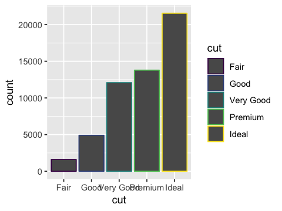

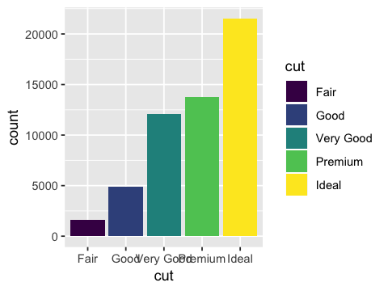

```r
ggplot(data = diamonds) +
  geom_bar(mapping = aes(x = cut, colour = cut))
ggplot(data = diamonds) +
  geom_bar(mapping = aes(x = cut, fill = cut))
```

Remmeber that we can "color by" a different variable - in the following case, clarity. By default, it stacks the bars for each clarity level. This is done using the positional adjustment specified by the position argument of geom_bar. If you don't want a stacked bar chart, you can use one of three other options: "identity", "dodge", or "fill".

[figure not shown]

```r
# ggplot() +
#   geom_bar()
```

*position = "identity"* This will place each object exactly where it falls in the context of the graph. This is not very useful for bars, because it overlaps them. To see that overlapping we either need to make the bars slightly transparent by setting alpha to a small value, or completely transparent by fill=NA

[figure not shown]

```r
# ggplot() +
#   geom_bar()
```

*position 'fill'* This works like stacking, but makes each set of stacked bars the same height. This makes it easier to compare proportions across groups.

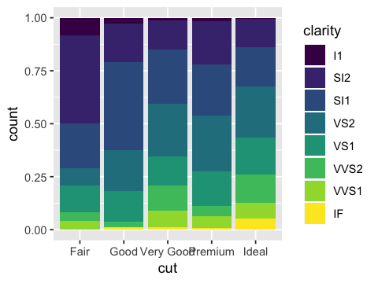

```r
ggplot(data = dm) +
  geom_bar(mapping = aes(x = cut, fill = clarity), position = "fill")
```

The plot below places overlapping objects directly beside one another, which makes it easier to compare individual values.

[figure not shown]

```r
# ggplot() +
#   geom_bar()
```

# Practice Midterm Solutions and two Additional Questions

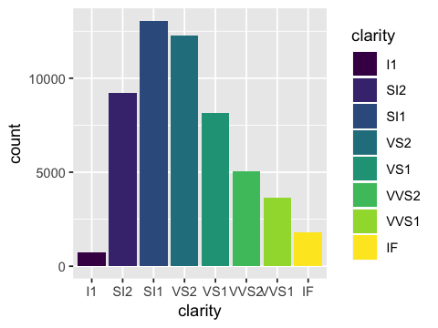

```r
# Problem 6
ggplot(data=diamonds, mapping=aes(x=clarity, fill=clarity)) +
    geom_bar()
```

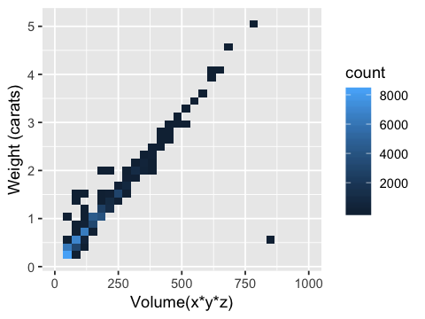

```r
# Problem 7
table7 = diamonds %>% mutate(Volume = x*y*z)
ggplot(data=table7, mapping=aes(x=Volume, y=carat)) +
    geom_bin2d() + xlim(0, 1000) +
    xlab('Volume(x*y*z)') + ylab('Weight (carats)')
```

```r
# Loading football data
load(url('https://github.com/terhorst/stats306/raw/master/ps4/cfb.RData'))
```

```r
# Reproducing table problem
year_mpg = mpg
head(year_mpg)
```

| manufacturer | model | displ | year | cyl | trans | drv | cty | hwy | fl | class |
| --- | --- | --- | --- | --- | --- | --- | --- | --- | --- | --- |
| audi | a4 | 1.8 | 1999 | 4 | auto(l5) | f | 18 | 29 | p | compact |
| audi | a4 | 1.8 | 1999 | 4 | manual(m5) | f | 21 | 29 | p | compact |
| audi | a4 | 2.0 | 2008 | 4 | manual(m6) | f | 20 | 31 | p | compact |
| audi | a4 | 2.0 | 2008 | 4 | auto(av) | f | 21 | 30 | p | compact |
| audi | a4 | 2.8 | 1999 | 6 | auto(l5) | f | 16 | 26 | p | compact |
| audi | a4 | 2.8 | 1999 | 6 | manual(m5) | f | 18 | 26 | p | compact |

```r
# Most 4WD problem
mpg %>% filter(year==1999, drv=='4') %>%
    group_by(manufacturer, year, drv) %>% summarize(total = n()) %>%
    arrange(desc(total))
```

| manufacturer | year | drv | total |
| --- | --- | --- | --- |
| dodge | 1999 | 4 | 10 |
| ford | 1999 | 4 | 9 |
| toyota | 1999 | 4 | 9 |
| subaru | 1999 | 4 | 6 |
| audi | 1999 | 4 | 5 |
| chevrolet | 1999 | 4 | 2 |
| jeep | 1999 | 4 | 2 |
| land rover | 1999 | 4 | 2 |
| mercury | 1999 | 4 | 2 |
| nissan | 1999 | 4 | 2 |

```r
colnames(cfb)
```

1. 'Year'

2. 'Game'

3. 'Count'

4. 'Conf Game'

5. 'Week'

6. 'Winning'

7. 'Winning Conference'

8. 'Winning H/A/N'

9. 'Winning Points'

10. 'Winning F/U'

11. 'Winning Cover'

12. 'Winning Spread'

13. 'Winning O/U'

14. 'Winning Passes'

15. 'Winning Pass Yards'

16. 'Winning YPPA'

17. 'Winning Rushes'

18. 'Winning Rush Yards'

19. 'Winning YPRA'

20. 'Winning Plays'

21. 'Winning Total Yards'

22. 'Winning YPP'

23. 'Winning TO'

24. 'Winning Pen Yards'

25. 'Winning TOP'

26. 'Field25'

27. 'Losing'

28. 'Losing Conference'

29. 'Losing H/A/N'

30. 'Losing Points'

31. 'Losing F/U'

32. 'Losing Cover'

33. 'Losing Spread'

34. 'Losing O/U'

35. 'Losing Passes'

36. 'Losing Pass Yards'

37. 'Losing YPPA'

38. 'Losing Rush Attempts'

39. 'Losing Rush Yards'

40. 'Losing YPRA'

41. 'Losing Total Plays'

42. 'Losing Total Yards'

43. 'Losing YPP'

44. 'Losing TO'

45. 'Losing Pen Yards'

46. 'Losing TOP'

47. 'OT?'

48. 'Thursday?'

49. 'TOP VERIFICATION'

50. 'O/U Total'

51. 'Tot Yard Dif'

52. 'TO Margin'

```r
# Finding Big 10 teams
cfb %>% filter(Year==2018) %>% unite(wconf, `Winning Conference`, Winning, sep="_") %>%
        unite(lconf, `Losing Conference`, Losing, sep="_") %>%
        gather(wconf, lconf, key="wl", value="conf_team") %>%
        separate(conf_team, into=c("Conference", "Team"), sep="_") %>%
        filter(Conference == "Big 10") %>% distinct(Team, Conference) %>% print
```

```
# A tibble: 14 x 2
   Conference Team
   <chr>      <chr>
 1 Big 10     Minnesota
 2 Big 10     Northwestern
 3 Big 10     Wisconsin
 4 Big 10     Michigan State
 5 Big 10     Ohio State
 6 Big 10     Penn State
 7 Big 10     Maryland
 8 Big 10     Illinois
 9 Big 10     Rutgers
10 Big 10     Iowa
11 Big 10     Indiana
12 Big 10     Michigan
13 Big 10     Purdue
14 Big 10     Nebraska
```

```r
require(nycflights13)
```

```r
# Rainyday
rainy_days <- group_by(weather, origin, year, month, day) %>%
              summarize(t=min(temp, na.rm=T), p=max(precip, na.rm=T)) %>%
              filter(p>0, t>32)
semi_join(flights, rainy_days) %>% nrow
```

90596

## Which month had the most missing departure time? How many are missing?

## In February, what percentage of flights with missing departure time were on snowy days?

Let's define snowy days to be similar to rainy days. a) the min temp is less than or equal to freezing and b) precipitation occured during one or more hours in the day